```python
%matplotlib inline
%load_ext autoreload
%autoreload 2

import numpy as np
import pandas as pd
import matplotlib.pyplot as plt
import seaborn as sns
from IPython.display import Markdown, display, HTML
from collections import defaultdict

import torch
import torch.nn as nn
import torch.optim as optim
from livelossplot import PlotLosses

# Fix the dying kernel problem (only a problem in some installations - you can remove it, if it works without it)
import os
os.environ['KMP_DUPLICATE_LIB_OK'] = 'True'
```

```python
import sys
import matplotlib as mpl
import IPython as ipyt
import livelossplot as llp
print('python', sys.version)
print('numpy', np.__version__)
print('pandas', pd.__version__)
print('matplotlib', mpl.__version__)
print('seaborn', sns.__version__)
print('IPython', ipyt.__version__)
print('torch', torch.__version__)
print('livelossplot', llp.__version__)
```

```
python 3.7.4 (default, Aug 13 2019, 20:35:49)
[GCC 7.3.0]
numpy 1.19.3
pandas 1.2.3
matplotlib 3.1.1
seaborn 0.11.1
IPython 7.8.0
torch 1.4.0
livelossplot 0.5.4
```

# Load the dataset for recommenders

```python
data_path = os.path.join("data", "hotel_data")

interactions_df = pd.read_csv(os.path.join(data_path, "hotel_data_interactions_df.csv"), index_col=0)

base_item_features = ['term', 'length_of_stay_bucket', 'rate_plan', 'room_segment', 'n_people_bucket', 'weekend_stay']

column_values_dict = {
    'term': ['WinterVacation', 'Easter', 'OffSeason', 'HighSeason', 'LowSeason', 'MayLongWeekend', 'NewYear', 'Christmas'],
    'length_of_stay_bucket': ['[0-1]', '[2-3]', '[4-7]', '[8-inf]'],
    'rate_plan': ['Standard', 'Nonref'],
    'room_segment': ['[0-160]', '[160-260]', '[260-360]', '[360-500]', '[500-900]'],
    'n_people_bucket': ['[1-1]', '[2-2]', '[3-4]', '[5-inf]'],
    'weekend_stay': ['True', 'False']
}

interactions_df.loc[:, 'term'] = pd.Categorical(
    interactions_df['term'], categories=column_values_dict['term'])
interactions_df.loc[:, 'length_of_stay_bucket'] = pd.Categorical(
    interactions_df['length_of_stay_bucket'], categories=column_values_dict['length_of_stay_bucket'])
interactions_df.loc[:, 'rate_plan'] = pd.Categorical(
    interactions_df['rate_plan'], categories=column_values_dict['rate_plan'])
interactions_df.loc[:, 'room_segment'] = pd.Categorical(
    interactions_df['room_segment'], categories=column_values_dict['room_segment'])
interactions_df.loc[:, 'n_people_bucket'] = pd.Categorical(
    interactions_df['n_people_bucket'], categories=column_values_dict['n_people_bucket'])
interactions_df.loc[:, 'weekend_stay'] = interactions_df['weekend_stay'].astype('str')
interactions_df.loc[:, 'weekend_stay'] = pd.Categorical(
    interactions_df['weekend_stay'], categories=column_values_dict['weekend_stay'])

display(HTML(interactions_df.head(15).to_html()))
```

|  | user_id | item_id | term | length_of_stay_bucket | rate_plan | room_segment | n_people_bucket | weekend_stay |
| --- | --- | --- | --- | --- | --- | --- | --- | --- |
| 0 | 1 | 0 | WinterVacation | [2-3] | Standard | [260-360] | [5-inf] | True |
| 1 | 2 | 1 | WinterVacation | [2-3] | Standard | [160-260] | [3-4] | True |
| 2 | 3 | 2 | WinterVacation | [2-3] | Standard | [160-260] | [2-2] | False |
| 3 | 4 | 3 | WinterVacation | [4-7] | Standard | [160-260] | [3-4] | True |
| 4 | 5 | 4 | WinterVacation | [4-7] | Standard | [0-160] | [2-2] | True |
| 5 | 6 | 5 | Easter | [4-7] | Standard | [260-360] | [5-inf] | True |
| 6 | 7 | 6 | OffSeason | [2-3] | Standard | [260-360] | [5-inf] | True |
| 7 | 8 | 7 | HighSeason | [2-3] | Standard | [160-260] | [1-1] | True |
| 8 | 9 | 8 | HighSeason | [2-3] | Standard | [0-160] | [1-1] | True |
| 9 | 8 | 7 | HighSeason | [2-3] | Standard | [160-260] | [1-1] | True |
| 10 | 8 | 7 | HighSeason | [2-3] | Standard | [160-260] | [1-1] | True |
| 11 | 10 | 9 | HighSeason | [2-3] | Standard | [160-260] | [3-4] | True |
| 12 | 11 | 9 | HighSeason | [2-3] | Standard | [160-260] | [3-4] | True |
| 13 | 12 | 10 | HighSeason | [8-inf] | Standard | [160-260] | [3-4] | True |
| 14 | 14 | 11 | HighSeason | [2-3] | Standard | [0-160] | [3-4] | True |

# (Optional) Prepare numerical user features

The method below is left here for convenience if you want to experiment with content-based user features as an input for your neural network.

```python
def n_to_p(l):
    n = sum(l)
    return [x / n for x in l] if n > 0 else l

def calculate_p(x, values):
    counts = [0]*len(values)
    for v in x:
        counts[values.index(v)] += 1

    return n_to_p(counts)

def prepare_users_df(interactions_df):

    users_df = interactions_df.loc[:, ["user_id"]]
    users_df = users_df.groupby("user_id").first().reset_index(drop=False)

    user_features = []

    for column in base_item_features:

        column_values = column_values_dict[column]
        df = interactions_df.loc[:, ['user_id', column]]
        df = df.groupby('user_id').aggregate(lambda x: list(x)).reset_index(drop=False)

        def calc_p(x):
            return calculate_p(x, column_values)

        df.loc[:, column] = df[column].apply(lambda x: calc_p(x))

        p_columns = []
        for i in range(len(column_values)):
            p_columns.append("user_" + column + "_" + column_values[i])
            df.loc[:, p_columns[i]] = df[column].apply(lambda x: x[i])
            user_features.append(p_columns[i])

        users_df = pd.merge(users_df, df.loc[:, ['user_id'] + p_columns], on=["user_id"])

    return users_df, user_features


users_df, user_features = prepare_users_df(interactions_df)

print(user_features)

display(HTML(users_df.loc[users_df['user_id'].isin([706, 1736, 7779, 96, 1, 50, 115])].head(15).to_html()))
```

```
['user_term_WinterVacation', 'user_term_Easter', 'user_term_OffSeason', 'user_term_HighSeason', 'user_term_LowSeason', 'user_term_MayLongWeekend', 'user_term_NewYear', 'user_term_Christmas', 'user_length_of_stay_bucket_[0-1]', 'user_length_of_stay_bucket_[2-3]', 'user_length_of_stay_bucket_[4-7]', '…
```

|  | user_id | user_term_WinterVacation | user_term_Easter | user_term_OffSeason | user_term_HighSeason | user_term_LowSeason | user_term_MayLongWeekend | user_term_NewYear | user_term_Christmas | user_length_of_stay_bucket_[0-1] | user_length_of_stay_bucket_[2-3] | user_length_of_stay_bucket_[4-7] | user_length_of_stay_bucket_[8-inf] | user_rate_plan_Standard | user_rate_plan_Nonref | user_room_segment_[0-160] | user_room_segment_[160-260] | user_room_segment_[260-360] | user_room_segment_[360-500] | user_room_segment_[500-900] | user_n_people_bucket_[1-1] | user_n_people_bucket_[2-2] | user_n_people_bucket_[3-4] | user_n_people_bucket_[5-inf] | user_weekend_stay_True | user_weekend_stay_False |
| --- | --- | --- | --- | --- | --- | --- | --- | --- | --- | --- | --- | --- | --- | --- | --- | --- | --- | --- | --- | --- | --- | --- | --- | --- | --- | --- |
| 0 | 1 | 0.130435 | 0.0 | 0.652174 | 0.086957 | 0.130435 | 0.000000 | 0.000000 | 0.000000 | 0.000000 | 0.608696 | 0.391304 | 0.000000 | 0.521739 | 0.478261 | 0.000000 | 0.869565 | 0.130435 | 0.000000 | 0.0 | 0.000000 | 0.739130 | 0.173913 | 0.086957 | 0.782609 | 0.217391 |
| 47 | 50 | 0.043478 | 0.0 | 0.434783 | 0.304348 | 0.217391 | 0.000000 | 0.000000 | 0.000000 | 0.000000 | 0.913043 | 0.086957 | 0.000000 | 0.260870 | 0.739130 | 0.000000 | 0.565217 | 0.434783 | 0.000000 | 0.0 | 0.000000 | 0.173913 | 0.521739 | 0.304348 | 0.782609 | 0.217391 |
| 92 | 96 | 0.083333 | 0.0 | 0.708333 | 0.125000 | 0.041667 | 0.041667 | 0.000000 | 0.000000 | 0.250000 | 0.666667 | 0.041667 | 0.041667 | 0.291667 | 0.708333 | 0.125000 | 0.791667 | 0.083333 | 0.000000 | 0.0 | 0.041667 | 0.333333 | 0.541667 | 0.083333 | 0.750000 | 0.250000 |
| 111 | 115 | 0.727273 | 0.0 | 0.272727 | 0.000000 | 0.000000 | 0.000000 | 0.000000 | 0.000000 | 0.500000 | 0.363636 | 0.136364 | 0.000000 | 1.000000 | 0.000000 | 0.000000 | 0.818182 | 0.181818 | 0.000000 | 0.0 | 0.818182 | 0.090909 | 0.045455 | 0.045455 | 0.363636 | 0.636364 |
| 675 | 706 | 0.091988 | 0.0 | 0.451039 | 0.189911 | 0.207715 | 0.038576 | 0.011869 | 0.008902 | 0.169139 | 0.459941 | 0.272997 | 0.097923 | 0.994065 | 0.005935 | 0.020772 | 0.839763 | 0.130564 | 0.008902 | 0.0 | 0.041543 | 0.094955 | 0.738872 | 0.124629 | 0.676558 | 0.323442 |
| 1699 | 1736 | 0.034483 | 0.0 | 0.482759 | 0.206897 | 0.275862 | 0.000000 | 0.000000 | 0.000000 | 0.241379 | 0.551724 | 0.206897 | 0.000000 | 0.172414 | 0.827586 | 0.000000 | 0.931034 | 0.068966 | 0.000000 | 0.0 | 0.379310 | 0.413793 | 0.206897 | 0.000000 | 0.448276 | 0.551724 |
| 7639 | 7779 | 0.037037 | 0.0 | 0.296296 | 0.259259 | 0.370370 | 0.000000 | 0.000000 | 0.037037 | 0.111111 | 0.296296 | 0.481481 | 0.111111 | 1.000000 | 0.000000 | 0.000000 | 0.814815 | 0.185185 | 0.000000 | 0.0 | 0.000000 | 0.037037 | 0.740741 | 0.222222 | 0.814815 | 0.185185 |

```python
from sklearn.preprocessing import OneHotEncoder
column_values_dict = {
    'term': ['WinterVacation', 'Easter', 'OffSeason', 'HighSeason', 'LowSeason', 'MayLongWeekend', 'NewYear', 'Christmas'],
    'length_of_stay_bucket': ['[0-1]', '[2-3]', '[4-7]', '[8-inf]'],
    'rate_plan': ['Standard', 'Nonref'],
    'room_segment': ['[0-160]', '[160-260]', '[260-360]', '[360-500]', '[500-900]'],
    'n_people_bucket': ['[1-1]', '[2-2]', '[3-4]', '[5-inf]'],
    'weekend_stay': ['True', 'False']
}
length_buckets = {'[0-1]': 1, '[2-3]' : 2, '[4-7]': 3, '[8-inf]': 4}
room_segments = {'[0-160]':1, '[160-260]':2, '[260-360]':3, '[360-500]':4, '[500-900]':5}
n_poeple_buckets = {'[1-1]':1, '[2-2]':2, '[3-4]':3, '[5-inf]':4}
display(HTML(interactions_df.head(15).to_html()))
def my_prepare_users_df(interactions_df):
    # Write your code here
    copy = interactions_df.copy()
    user_features = ['avg_length_of_stay', 'avg_room_segment', 'avg_n_people']
    copy.loc[:, 'lsb_val'] = copy['length_of_stay_bucket'].apply(
        lambda x: length_buckets[x]
    )
    copy['lsb_val'] = copy['lsb_val'].astype("float")

    copy.loc[:, 'rs_val'] = copy['room_segment'].apply(
        lambda x: room_segments.get(x, 5)
    )
    copy['rs_val'] = copy['rs_val'].astype("float")

    copy.loc[:, 'npb_val'] = copy['n_people_bucket'].apply(
        lambda x: n_poeple_buckets[x]
    )
    copy['npb_val'] = copy['npb_val'].astype("float")
    users_df = copy.groupby('user_id')[['lsb_val', 'rs_val', 'npb_val']].mean().reset_index()
    users_df.columns = ['user_id'] + user_features
    display(HTML(users_df.head(15).to_html()))
    return users_df, user_features


users_df, user_features = my_prepare_users_df(interactions_df)

print(user_features)

display(HTML(users_df.loc[users_df['user_id'].isin([706, 1736, 7779, 96, 1, 50, 115])].head(15).to_html()))
```

|  | user_id | item_id | term | length_of_stay_bucket | rate_plan | room_segment | n_people_bucket | weekend_stay |
| --- | --- | --- | --- | --- | --- | --- | --- | --- |
| 0 | 1 | 0 | WinterVacation | [2-3] | Standard | [260-360] | [5-inf] | True |
| 1 | 2 | 1 | WinterVacation | [2-3] | Standard | [160-260] | [3-4] | True |
| 2 | 3 | 2 | WinterVacation | [2-3] | Standard | [160-260] | [2-2] | False |
| 3 | 4 | 3 | WinterVacation | [4-7] | Standard | [160-260] | [3-4] | True |
| 4 | 5 | 4 | WinterVacation | [4-7] | Standard | [0-160] | [2-2] | True |
| 5 | 6 | 5 | Easter | [4-7] | Standard | [260-360] | [5-inf] | True |
| 6 | 7 | 6 | OffSeason | [2-3] | Standard | [260-360] | [5-inf] | True |
| 7 | 8 | 7 | HighSeason | [2-3] | Standard | [160-260] | [1-1] | True |
| 8 | 9 | 8 | HighSeason | [2-3] | Standard | [0-160] | [1-1] | True |
| 9 | 8 | 7 | HighSeason | [2-3] | Standard | [160-260] | [1-1] | True |
| 10 | 8 | 7 | HighSeason | [2-3] | Standard | [160-260] | [1-1] | True |
| 11 | 10 | 9 | HighSeason | [2-3] | Standard | [160-260] | [3-4] | True |
| 12 | 11 | 9 | HighSeason | [2-3] | Standard | [160-260] | [3-4] | True |
| 13 | 12 | 10 | HighSeason | [8-inf] | Standard | [160-260] | [3-4] | True |
| 14 | 14 | 11 | HighSeason | [2-3] | Standard | [0-160] | [3-4] | True |

|  | user_id | avg_length_of_stay | avg_room_segment | avg_n_people |
| --- | --- | --- | --- | --- |
| 0 | 1 | 2.391304 | 2.130435 | 2.347826 |
| 1 | 2 | 2.000000 | 2.000000 | 3.000000 |
| 2 | 3 | 2.000000 | 2.000000 | 2.000000 |
| 3 | 4 | 3.000000 | 2.000000 | 3.000000 |
| 4 | 5 | 3.000000 | 1.000000 | 2.000000 |
| 5 | 6 | 3.000000 | 3.000000 | 4.000000 |
| 6 | 7 | 2.000000 | 3.000000 | 4.000000 |
| 7 | 8 | 2.000000 | 2.000000 | 1.000000 |
| 8 | 9 | 2.000000 | 1.000000 | 1.000000 |
| 9 | 10 | 2.000000 | 2.000000 | 3.000000 |
| 10 | 11 | 2.000000 | 2.000000 | 3.000000 |
| 11 | 12 | 4.000000 | 2.000000 | 3.000000 |
| 12 | 13 | 2.400000 | 2.100000 | 1.000000 |
| 13 | 14 | 2.000000 | 1.000000 | 3.000000 |
| 14 | 15 | 2.000000 | 2.000000 | 4.000000 |

```
['avg_length_of_stay', 'avg_room_segment', 'avg_n_people']
```

|  | user_id | avg_length_of_stay | avg_room_segment | avg_n_people |
| --- | --- | --- | --- | --- |
| 0 | 1 | 2.391304 | 2.130435 | 2.347826 |
| 47 | 50 | 2.086957 | 2.434783 | 3.130435 |
| 92 | 96 | 1.875000 | 1.958333 | 2.666667 |
| 111 | 115 | 1.636364 | 2.181818 | 1.318182 |
| 675 | 706 | 2.299703 | 2.127596 | 2.946588 |
| 1699 | 1736 | 1.965517 | 2.068966 | 1.827586 |
| 7639 | 7779 | 2.592593 | 2.185185 | 3.185185 |

# (Optional) Prepare numerical item features

The method below is left here for convenience if you want to experiment with content-based item features as an input for your neural network.

```python
def map_items_to_onehot(df):
    one_hot = pd.get_dummies(df.loc[:, base_item_features])
    df = df.drop(base_item_features, axis = 1)
    df = df.join(one_hot)

    return df, list(one_hot.columns)

def prepare_items_df(interactions_df):
    items_df = interactions_df.loc[:, ["item_id"] + base_item_features].drop_duplicates()

    items_df, item_features = map_items_to_onehot(items_df)

    return items_df, item_features


items_df, item_features = prepare_items_df(interactions_df)

print(item_features)

display(HTML(items_df.loc[items_df['item_id'].isin([0, 1, 2, 3, 4, 5, 6])].head(15).to_html()))
```

```
['term_WinterVacation', 'term_Easter', 'term_OffSeason', 'term_HighSeason', 'term_LowSeason', 'term_MayLongWeekend', 'term_NewYear', 'term_Christmas', 'length_of_stay_bucket_[0-1]', 'length_of_stay_bucket_[2-3]', 'length_of_stay_bucket_[4-7]', 'length_of_stay_bucket_[8-inf]', 'rate_plan_Standard', '…
```

|  | item_id | term_WinterVacation | term_Easter | term_OffSeason | term_HighSeason | term_LowSeason | term_MayLongWeekend | term_NewYear | term_Christmas | length_of_stay_bucket_[0-1] | length_of_stay_bucket_[2-3] | length_of_stay_bucket_[4-7] | length_of_stay_bucket_[8-inf] | rate_plan_Standard | rate_plan_Nonref | room_segment_[0-160] | room_segment_[160-260] | room_segment_[260-360] | room_segment_[360-500] | room_segment_[500-900] | n_people_bucket_[1-1] | n_people_bucket_[2-2] | n_people_bucket_[3-4] | n_people_bucket_[5-inf] | weekend_stay_True | weekend_stay_False |
| --- | --- | --- | --- | --- | --- | --- | --- | --- | --- | --- | --- | --- | --- | --- | --- | --- | --- | --- | --- | --- | --- | --- | --- | --- | --- | --- |
| 0 | 0 | 1 | 0 | 0 | 0 | 0 | 0 | 0 | 0 | 0 | 1 | 0 | 0 | 1 | 0 | 0 | 0 | 1 | 0 | 0 | 0 | 0 | 0 | 1 | 1 | 0 |
| 1 | 1 | 1 | 0 | 0 | 0 | 0 | 0 | 0 | 0 | 0 | 1 | 0 | 0 | 1 | 0 | 0 | 1 | 0 | 0 | 0 | 0 | 0 | 1 | 0 | 1 | 0 |
| 2 | 2 | 1 | 0 | 0 | 0 | 0 | 0 | 0 | 0 | 0 | 1 | 0 | 0 | 1 | 0 | 0 | 1 | 0 | 0 | 0 | 0 | 1 | 0 | 0 | 0 | 1 |
| 3 | 3 | 1 | 0 | 0 | 0 | 0 | 0 | 0 | 0 | 0 | 0 | 1 | 0 | 1 | 0 | 0 | 1 | 0 | 0 | 0 | 0 | 0 | 1 | 0 | 1 | 0 |
| 4 | 4 | 1 | 0 | 0 | 0 | 0 | 0 | 0 | 0 | 0 | 0 | 1 | 0 | 1 | 0 | 1 | 0 | 0 | 0 | 0 | 0 | 1 | 0 | 0 | 1 | 0 |
| 5 | 5 | 0 | 1 | 0 | 0 | 0 | 0 | 0 | 0 | 0 | 0 | 1 | 0 | 1 | 0 | 0 | 0 | 1 | 0 | 0 | 0 | 0 | 0 | 1 | 1 | 0 |
| 6 | 6 | 0 | 0 | 1 | 0 | 0 | 0 | 0 | 0 | 0 | 1 | 0 | 0 | 1 | 0 | 0 | 0 | 1 | 0 | 0 | 0 | 0 | 0 | 1 | 1 | 0 |

# Neural network recommender

**Task:**  
Code a recommender based on a neural network model. You are free to choose any network architecture you find appropriate. The network can use the interaction vectors for users and items, embeddings of users and items, as well as user and item features (you can use the features you developed in the first project).

Remember to keep control over randomness - in the init method add the seed as a parameter and initialize the random seed generator with that seed (both for numpy and pytorch):

```
self.seed = seed
self.rng = np.random.RandomState(seed=seed)
```

in the network model:

```
self.seed = torch.manual_seed(seed)
```

You are encouraged to experiment with:

- the number of layers in the network, the number of neurons and different activation functions,
- different optimizers and their parameters,
- batch size and the number of epochs,
- embedding layers,
- content-based features of both users and items.

```python
class Net(nn.Module):
    def __init__(self, seed=6789):
        super().__init__()

        self.seed = torch.manual_seed(seed)
        self.fc = nn.Linear(28, 4, bias=False)
#         self.fc2 = nn.Linear(4, 4, bias=False)
        self.fc3 = nn.Linear(4, 1, bias=False)
#         self.fc.weight.data = torch.ones(50, requires_grad=True)

    def forward(self, x):
        x = torch.sigmoid(self.fc(x))
#         x = torch.sigmoid(self.fc2(x))
        x = torch.sigmoid(self.fc3(x))
        return x
```

```python
from recommenders.recommender import Recommender


class NNRecommender(Recommender):
    """
    Linear recommender class based on user and item features.
    """

    def __init__(self, seed=6789, n_neg_per_pos=3):
        """
        Initialize base recommender params and variables.
        """
        self.model = None
        self.n_neg_per_pos = n_neg_per_pos

        self.recommender_df = pd.DataFrame(columns=['user_id', 'item_id', 'score'])
        self.users_df = None
        self.user_features = None

        self.seed = seed
        self.rng = np.random.RandomState(seed=seed)

    def fit(self, interactions_df, users_df, items_df):
        """
        Training of the recommender.

        :param pd.DataFrame interactions_df: DataFrame with recorded interactions between users and items
            defined by user_id, item_id and features of the interaction.
        :param pd.DataFrame users_df: DataFrame with users and their features defined by user_id and the user feature columns.
        :param pd.DataFrame items_df: DataFrame with items and their features defined by item_id and the item feature columns.
        """

        interactions_df = interactions_df.copy()

        # Prepare users_df and items_df
        # (optional - use only if you want to train a hybrid model with content-based features)

#         users_df, user_features = prepare_users_df(interactions_df)
        users_df, user_features = my_prepare_users_df(interactions_df)

        self.users_df = users_df
        self.user_features = user_features

        items_df, item_features = prepare_items_df(interactions_df)
        items_df = items_df.loc[:, ['item_id'] + item_features]
#         display(HTML(items_df.head(15).to_html()))

        # Generate negative interactions

        # <<<Write your code here>>>
        print('start negative')
        negative_interactions = []
        interactions_df.loc[:, 'interacted'] = 1
        existed = interactions_df.copy().drop(columns='interacted')
        max_user_id = existed['user_id'].max()
        max_item_id = existed['item_id'].max()
        while len(negative_interactions) != self.n_neg_per_pos*len(interactions_df):
            rand_user = self.rng.randint(0, max_user_id)
            rand_item = self.rng.randint(0, max_item_id)
            if not ((existed['user_id'] == rand_user) & (existed['item_id'] == rand_item)).any():
                negative_interactions.append((rand_user, rand_item, 0))
        print('end negative')
        interactions_df = pd.concat(
            [interactions_df, pd.DataFrame(negative_interactions, columns=['user_id', 'item_id', 'interacted'])])

        # Merge user and item features
        # (optional - use only if you want to train a hybrid model with content-based features)

        interactions_df = pd.merge(interactions_df, users_df, on=['user_id'])
        interactions_df = pd.merge(interactions_df, items_df, on=['item_id'])

        # Initialize the neural network model

        # <<<Write your code here>>>
        self.model = Net(seed=self.seed)

        # Train the model using an optimizer

        # <<<Write your code here>>>
        x = interactions_df.loc[:, user_features + item_features].values
        x = torch.from_numpy(x)
        y_target = torch.from_numpy(interactions_df['interacted'].to_numpy())
        optimizer = optim.SGD(self.model.parameters(), lr=0.1)
        losses = []
        n_epochs = 3
        print('x.len', len(x))
        print('x[0]', x[0])
        print('ytarget.len', len(y_target))
        for epoch in range(n_epochs):
            print('epoch', epoch)
            optimizer.zero_grad()
            for i in range(len(x)):
                y = self.model(x[i].float())
                if i == 0 or i == 1:
                    loss = torch.pow(y - y_target[i], 2)
                    print('y=', y)
                    print('y_target=', y_target[i])
                else:
                    loss += torch.pow(y - y_target[i], 2)
            for param in self.model.parameters():
                loss += (1/5 * torch.norm(param))
            loss = loss.sum()
#             y = self.model(x.float())
#             loss = torch.pow(y - y_target, 2).sum()
            loss.backward()
            print('loss=', loss)
            losses.append(loss.item())
            optimizer.step()
        sns.lineplot(x=np.arange(n_epochs), y=losses).set_title('Training loss')
        plt.xlabel("epoch")
        plt.ylabel("loss")
        plt.show()

    def recommend(self, users_df, items_df, n_recommendations=1):
        """
        Serving of recommendations. Scores items in items_df for each user in users_df and returns
        top n_recommendations for each user.

        :param pd.DataFrame users_df: DataFrame with users and their features for which recommendations should be generated.
        :param pd.DataFrame items_df: DataFrame with items and their features which should be scored.
        :param int n_recommendations: Number of recommendations to be returned for each user.
        :return: DataFrame with user_id, item_id and score as columns returning n_recommendations top recommendations
            for each user.
        :rtype: pd.DataFrame
        """
#         print('start recommend')
        # Clean previous recommendations (iloc could be used alternatively)
        self.recommender_df = self.recommender_df[:0]

        # Prepare users_df and items_df
        # (optional - use only if you want to train a hybrid model with content-based features)

        users_df = users_df.loc[:, 'user_id']
        users_df = pd.merge(users_df, self.users_df, on=['user_id'], how='left').fillna(0)

        items_df, item_features = prepare_items_df(items_df)
        items_df = items_df.loc[:, ['item_id'] + item_features]

        # Score the items

        recommendations = pd.DataFrame(columns=['user_id', 'item_id', 'score'])
        index = 0
        for ix, user in users_df.iterrows():
#             print(ix)
#             if index % 100 == 0:
#                 print('user=', user)
            # Calculate the score for the user and every item in items_df
            user_df = user.to_frame().transpose()
            temp = pd.merge(user_df, items_df, how='cross')
            cartesian = temp.drop(columns=['user_id', 'item_id'])
            cartesian = torch.from_numpy(cartesian.to_numpy())

            scores = self.model(cartesian.float())
            scores = scores.cpu().detach().numpy()
#             print('scores', scores)
#             idx = (-scores).argsort()[:n_recommendations]
#             chosen_ids = temp.iloc[idx]['item_id']
            chosen_ids = (-scores).argsort()[:n_recommendations]

            recommendations = []
            for item_id in chosen_ids:
                recommendations.append(
                    {
                        'user_id': user['user_id'],
                        'item_id': item_id[0],
                        'score': scores[item_id]
                    }
                )

            user_recommendations = pd.DataFrame(recommendations)

            self.recommender_df = pd.concat([self.recommender_df, user_recommendations])
            index += 1

        return self.recommender_df
```

# Quick test of the recommender

```python
items_df = interactions_df.loc[:, ['item_id'] + base_item_features].drop_duplicates()
```

|  | user_id | avg_length_of_stay | avg_room_segment | avg_n_people |
| --- | --- | --- | --- | --- |
| 0 | 1 | 2.391304 | 2.130435 | 2.347826 |
| 1 | 2 | 2.000000 | 2.000000 | 3.000000 |
| 2 | 3 | 2.000000 | 2.000000 | 2.000000 |
| 3 | 4 | 3.000000 | 2.000000 | 3.000000 |
| 4 | 5 | 3.000000 | 1.000000 | 2.000000 |
| 5 | 6 | 3.000000 | 3.000000 | 4.000000 |
| 6 | 7 | 2.000000 | 3.000000 | 4.000000 |
| 7 | 8 | 2.000000 | 2.000000 | 1.000000 |
| 8 | 9 | 2.000000 | 1.000000 | 1.000000 |
| 9 | 10 | 2.000000 | 2.000000 | 3.000000 |
| 10 | 11 | 2.000000 | 2.000000 | 3.000000 |
| 11 | 12 | 4.000000 | 2.000000 | 3.000000 |
| 12 | 13 | 2.400000 | 2.100000 | 1.000000 |
| 13 | 14 | 2.000000 | 1.000000 | 3.000000 |
| 14 | 15 | 2.000000 | 2.000000 | 4.000000 |

```
start negative
end negative
x.len 63314
x[0] tensor([2.3913, 2.1304, 2.3478, 1.0000, 0.0000, 0.0000, 0.0000, 0.0000, 0.0000,
        0.0000, 0.0000, 0.0000, 1.0000, 0.0000, 0.0000, 1.0000, 0.0000, 0.0000,
        0.0000, 1.0000, 0.0000, 0.0000, 0.0000, 0.0000, 0.0000, 1.0000, 1.0000,
        0.0000], dtype=torch.float64)
ytarget.len 63314
epoch 0
y= tensor([0.6206], grad_fn=<SigmoidBackward>)
y_target= tensor(1)
y= tensor([0.6190], grad_fn=<SigmoidBackward>)
y_target= tensor(0)
loss= tensor(20813.9512, grad_fn=<SumBackward0>)
epoch 1
y= tensor([0.], grad_fn=<SigmoidBackward>)
y_target= tensor(1)
y= tensor([0.], grad_fn=<SigmoidBackward>)
y_target= tensor(0)
loss= tensor(16485.9902, grad_fn=<SumBackward0>)
epoch 2
y= tensor([0.], grad_fn=<SigmoidBackward>)
y_target= tensor(1)
y= tensor([0.], grad_fn=<SigmoidBackward>)
y_target= tensor(0)
loss= tensor(16485.9824, grad_fn=<SumBackward0>)
```

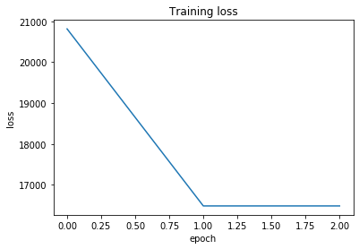

```python
# Fit method
nn_recommender = NNRecommender()
nn_recommender.fit(interactions_df, None, None)
```

```python
# Recommender method

recommendations = nn_recommender.recommend(pd.DataFrame([[1], [2], [3], [4], [5]], columns=['user_id']), items_df, 10)
display(HTML(recommendations.to_html()))
# display(HTML(items_df.to_html()))
# recommendations = pd.merge(recommendations, items_df, on='item_id', how='left')
# display(HTML(recommendations.to_html()))
```

|  | user_id | item_id | score |
| --- | --- | --- | --- |
| 0 | 1.0 | 0 | [[0.0]] |
| 1 | 1.0 | 0 | [[0.0]] |
| 2 | 1.0 | 0 | [[0.0]] |
| 3 | 1.0 | 0 | [[0.0]] |
| 4 | 1.0 | 0 | [[0.0]] |
| 5 | 1.0 | 0 | [[0.0]] |
| 6 | 1.0 | 0 | [[0.0]] |
| 7 | 1.0 | 0 | [[0.0]] |
| 8 | 1.0 | 0 | [[0.0]] |
| 9 | 1.0 | 0 | [[0.0]] |
| 0 | 2.0 | 0 | [[0.0]] |
| 1 | 2.0 | 0 | [[0.0]] |
| 2 | 2.0 | 0 | [[0.0]] |
| 3 | 2.0 | 0 | [[0.0]] |
| 4 | 2.0 | 0 | [[0.0]] |
| 5 | 2.0 | 0 | [[0.0]] |
| 6 | 2.0 | 0 | [[0.0]] |
| 7 | 2.0 | 0 | [[0.0]] |
| 8 | 2.0 | 0 | [[0.0]] |
| 9 | 2.0 | 0 | [[0.0]] |
| 0 | 3.0 | 0 | [[0.0]] |
| 1 | 3.0 | 0 | [[0.0]] |
| 2 | 3.0 | 0 | [[0.0]] |
| 3 | 3.0 | 0 | [[0.0]] |
| 4 | 3.0 | 0 | [[0.0]] |
| 5 | 3.0 | 0 | [[0.0]] |
| 6 | 3.0 | 0 | [[0.0]] |
| 7 | 3.0 | 0 | [[0.0]] |
| 8 | 3.0 | 0 | [[0.0]] |
| 9 | 3.0 | 0 | [[0.0]] |
| 0 | 4.0 | 0 | [[0.0]] |
| 1 | 4.0 | 0 | [[0.0]] |
| 2 | 4.0 | 0 | [[0.0]] |
| 3 | 4.0 | 0 | [[0.0]] |
| 4 | 4.0 | 0 | [[0.0]] |
| 5 | 4.0 | 0 | [[0.0]] |
| 6 | 4.0 | 0 | [[0.0]] |
| 7 | 4.0 | 0 | [[0.0]] |
| 8 | 4.0 | 0 | [[0.0]] |
| 9 | 4.0 | 0 | [[0.0]] |
| 0 | 5.0 | 0 | [[0.0]] |
| 1 | 5.0 | 0 | [[0.0]] |
| 2 | 5.0 | 0 | [[0.0]] |
| 3 | 5.0 | 0 | [[0.0]] |
| 4 | 5.0 | 0 | [[0.0]] |
| 5 | 5.0 | 0 | [[0.0]] |
| 6 | 5.0 | 0 | [[0.0]] |
| 7 | 5.0 | 0 | [[0.0]] |
| 8 | 5.0 | 0 | [[0.0]] |
| 9 | 5.0 | 0 | [[0.0]] |

# Tuning method

```python
from evaluation_and_testing.testing import evaluate_train_test_split_implicit

seed = 6789
```

```python
from hyperopt import hp, fmin, tpe, Trials
import traceback

def tune_recommender(recommender_class, interactions_df, items_df,
                     param_space, max_evals=1, show_progressbar=True, seed=6789):
    # Split into train_validation and test sets

    shuffle = np.arange(len(interactions_df))
    rng = np.random.RandomState(seed=seed)
    rng.shuffle(shuffle)
    shuffle = list(shuffle)

    train_test_split = 0.8
    split_index = int(len(interactions_df) * train_test_split)

    train_validation = interactions_df.iloc[shuffle[:split_index]]
    test = interactions_df.iloc[shuffle[split_index:]]

    # Tune

    def loss(tuned_params):
        recommender = recommender_class(seed=seed, **tuned_params)
        hr1, hr3, hr5, hr10, ndcg1, ndcg3, ndcg5, ndcg10 = evaluate_train_test_split_implicit(
            recommender, train_validation, items_df, seed=seed)
        return -hr10

    n_tries = 1
    succeded = False
    try_id = 0
    while not succeded and try_id < n_tries:
        try:
            trials = Trials()
            best_param_set = fmin(loss, space=param_space, algo=tpe.suggest,
                                  max_evals=max_evals, show_progressbar=show_progressbar, trials=trials, verbose=True)
            succeded = True
        except:
            traceback.print_exc()
            try_id += 1

    if not succeded:
        return None

    # Validate

    recommender = recommender_class(seed=seed, **best_param_set)

    results = [[recommender_class.__name__] + list(evaluate_train_test_split_implicit(
        recommender, {'train': train_validation, 'test': test}, items_df, seed=seed))]

    results = pd.DataFrame(results,
                           columns=['Recommender', 'HR@1', 'HR@3', 'HR@5', 'HR@10', 'NDCG@1', 'NDCG@3', 'NDCG@5', 'NDCG@10'])

    display(HTML(results.to_html()))

    return best_param_set
```

## Tuning of the recommender

**Task:**  
Tune your model using the code below. You only need to put the class name of your recommender and choose an appropriate parameter space.

|  | user_id | avg_length_of_stay | avg_room_segment | avg_n_people |
| --- | --- | --- | --- | --- |
| 0 | 1 | 2.285714 | 2.0 | 2.214286 |
| 1 | 3 | 2.000000 | 2.0 | 2.000000 |
| 2 | 4 | 3.000000 | 2.0 | 3.000000 |
| 3 | 5 | 3.000000 | 1.0 | 2.000000 |
| 4 | 6 | 3.000000 | 3.0 | 4.000000 |
| 5 | 7 | 2.000000 | 3.0 | 4.000000 |
| 6 | 8 | 2.000000 | 2.0 | 1.000000 |
| 7 | 10 | 2.000000 | 2.0 | 3.000000 |
| 8 | 12 | 4.000000 | 2.0 | 3.000000 |
| 9 | 13 | 2.285714 | 2.0 | 1.000000 |
| 10 | 18 | 4.000000 | 2.0 | 3.000000 |
| 11 | 19 | 3.000000 | 2.0 | 3.000000 |
| 12 | 20 | 4.000000 | 3.0 | 4.000000 |
| 13 | 25 | 3.000000 | 2.0 | 3.000000 |
| 14 | 26 | 2.000000 | 3.0 | 1.000000 |

```
start negative
end negative
x.len
69475
x[0]
tensor([3., 3., 4., 0., 1., 0., 0., 0., 0., 0., 0., 0., 0., 1., 0., 1., 0., 0.,
        0., 1., 0., 0., 0., 0., 0., 1., 1., 0.], dtype=torch.float64)
ytarget.len
69475
epoch
0
y=
tensor([0.6191], grad_fn=<SigmoidBackward>)
y_target=
tensor(1)
y=
tensor([0.6140], grad_fn=<SigmoidBackward>)
y_target=
tensor(0)
loss=
tensor(24703.9980, grad_fn=<SumBackward0>)
epoch
1
y=
tensor([0.], grad_fn=<SigmoidBackward>)
y_target=
tensor(1)
y=
tensor([0.], grad_fn=<SigmoidBackward>)
y_target=
tensor(0)
loss=
tensor(10845.8389, grad_fn=<SumBackward0>)
epoch
2
y=
tensor([0.], grad_fn=<SigmoidBackward>)
y_target=
tensor(1)
y=
tensor([0.], grad_fn=<SigmoidBackward>)
y_target=
tensor(0)
loss=
tensor(10845.8311, grad_fn=<SumBackward0>)
```

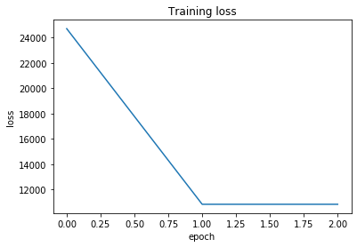

|  | user_id | avg_length_of_stay | avg_room_segment | avg_n_people |
| --- | --- | --- | --- | --- |
| 0 | 1 | 2.285714 | 2.0 | 2.214286 |
| 1 | 3 | 2.000000 | 2.0 | 2.000000 |
| 2 | 4 | 3.000000 | 2.0 | 3.000000 |
| 3 | 5 | 3.000000 | 1.0 | 2.000000 |
| 4 | 6 | 3.000000 | 3.0 | 4.000000 |
| 5 | 7 | 2.000000 | 3.0 | 4.000000 |
| 6 | 8 | 2.000000 | 2.0 | 1.000000 |
| 7 | 10 | 2.000000 | 2.0 | 3.000000 |
| 8 | 12 | 4.000000 | 2.0 | 3.000000 |
| 9 | 13 | 2.285714 | 2.0 | 1.000000 |
| 10 | 18 | 4.000000 | 2.0 | 3.000000 |
| 11 | 19 | 3.000000 | 2.0 | 3.000000 |
| 12 | 20 | 4.000000 | 3.0 | 4.000000 |
| 13 | 25 | 3.000000 | 2.0 | 3.000000 |
| 14 | 26 | 2.000000 | 3.0 | 1.000000 |

```
start negative
end negative
x.len
22209
x[0]
tensor([3., 3., 4., 0., 1., 0., 0., 0., 0., 0., 0., 0., 0., 1., 0., 1., 0., 0.,
        0., 1., 0., 0., 0., 0., 0., 1., 1., 0.], dtype=torch.float64)
ytarget.len
22209
epoch
0
y=
tensor([0.6191], grad_fn=<SigmoidBackward>)
y_target=
tensor(1)
y=
tensor([0.6131], grad_fn=<SigmoidBackward>)
y_target=
tensor(0)
loss=
tensor(6116.5132, grad_fn=<SumBackward0>)
epoch
1
y=
tensor([1.7353e-28], grad_fn=<SigmoidBackward>)
y_target=
tensor(1)
y=
tensor([1.7353e-28], grad_fn=<SigmoidBackward>)
y_target=
tensor(0)
loss=
tensor(10362.3857, grad_fn=<SumBackward0>)
epoch
2
y=
tensor([1.7474e-28], grad_fn=<SigmoidBackward>)
y_target=
tensor(1)
y=
tensor([1.7474e-28], grad_fn=<SigmoidBackward>)
y_target=
tensor(0)
loss=
tensor(10362.3770, grad_fn=<SumBackward0>)
```

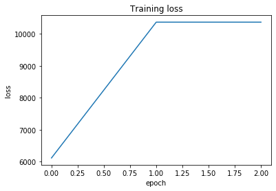

|  | user_id | avg_length_of_stay | avg_room_segment | avg_n_people |
| --- | --- | --- | --- | --- |
| 0 | 1 | 2.285714 | 2.0 | 2.214286 |
| 1 | 3 | 2.000000 | 2.0 | 2.000000 |
| 2 | 4 | 3.000000 | 2.0 | 3.000000 |
| 3 | 5 | 3.000000 | 1.0 | 2.000000 |
| 4 | 6 | 3.000000 | 3.0 | 4.000000 |
| 5 | 7 | 2.000000 | 3.0 | 4.000000 |
| 6 | 8 | 2.000000 | 2.0 | 1.000000 |
| 7 | 10 | 2.000000 | 2.0 | 3.000000 |
| 8 | 12 | 4.000000 | 2.0 | 3.000000 |
| 9 | 13 | 2.285714 | 2.0 | 1.000000 |
| 10 | 18 | 4.000000 | 2.0 | 3.000000 |
| 11 | 19 | 3.000000 | 2.0 | 3.000000 |
| 12 | 20 | 4.000000 | 3.0 | 4.000000 |
| 13 | 25 | 3.000000 | 2.0 | 3.000000 |
| 14 | 26 | 2.000000 | 3.0 | 1.000000 |

```
start negative
end negative
x.len
34058
x[0]
tensor([3., 3., 4., 0., 1., 0., 0., 0., 0., 0., 0., 0., 0., 1., 0., 1., 0., 0.,
        0., 1., 0., 0., 0., 0., 0., 1., 1., 0.], dtype=torch.float64)
ytarget.len
34058
epoch
0
y=
tensor([0.6191], grad_fn=<SigmoidBackward>)
y_target=
tensor(1)
y=
tensor([0.6140], grad_fn=<SigmoidBackward>)
y_target=
tensor(0)
loss=
tensor(10776.6904, grad_fn=<SumBackward0>)
epoch
1
y=
tensor([0.], grad_fn=<SigmoidBackward>)
y_target=
tensor(1)
y=
tensor([0.], grad_fn=<SigmoidBackward>)
y_target=
tensor(0)
loss=
tensor(10483.4609, grad_fn=<SumBackward0>)
epoch
2
y=
tensor([0.], grad_fn=<SigmoidBackward>)
y_target=
tensor(1)
y=
tensor([0.], grad_fn=<SigmoidBackward>)
y_target=
tensor(0)
loss=
tensor(10483.4531, grad_fn=<SumBackward0>)
```

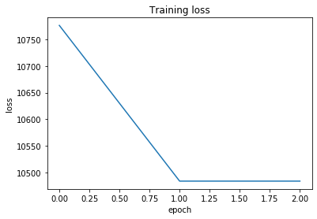

|  | user_id | avg_length_of_stay | avg_room_segment | avg_n_people |
| --- | --- | --- | --- | --- |
| 0 | 1 | 2.285714 | 2.0 | 2.214286 |
| 1 | 3 | 2.000000 | 2.0 | 2.000000 |
| 2 | 4 | 3.000000 | 2.0 | 3.000000 |
| 3 | 5 | 3.000000 | 1.0 | 2.000000 |
| 4 | 6 | 3.000000 | 3.0 | 4.000000 |
| 5 | 7 | 2.000000 | 3.0 | 4.000000 |
| 6 | 8 | 2.000000 | 2.0 | 1.000000 |
| 7 | 10 | 2.000000 | 2.0 | 3.000000 |
| 8 | 12 | 4.000000 | 2.0 | 3.000000 |
| 9 | 13 | 2.285714 | 2.0 | 1.000000 |
| 10 | 18 | 4.000000 | 2.0 | 3.000000 |
| 11 | 19 | 3.000000 | 2.0 | 3.000000 |
| 12 | 20 | 4.000000 | 3.0 | 4.000000 |
| 13 | 25 | 3.000000 | 2.0 | 3.000000 |
| 14 | 26 | 2.000000 | 3.0 | 1.000000 |

```
start negative
end negative
x.len
51835
x[0]
tensor([3., 3., 4., 0., 1., 0., 0., 0., 0., 0., 0., 0., 0., 1., 0., 1., 0., 0.,
        0., 1., 0., 0., 0., 0., 0., 1., 1., 0.], dtype=torch.float64)
ytarget.len
51835
epoch
0
y=
tensor([0.6191], grad_fn=<SigmoidBackward>)
y_target=
tensor(1)
y=
tensor([0.6140], grad_fn=<SigmoidBackward>)
y_target=
tensor(0)
loss=
tensor(17767.0996, grad_fn=<SumBackward0>)
epoch
1
y=
tensor([0.], grad_fn=<SigmoidBackward>)
y_target=
tensor(1)
y=
tensor([0.], grad_fn=<SigmoidBackward>)
y_target=
tensor(0)
loss=
tensor(10665.3418, grad_fn=<SumBackward0>)
epoch
2
y=
tensor([0.], grad_fn=<SigmoidBackward>)
y_target=
tensor(1)
y=
tensor([0.], grad_fn=<SigmoidBackward>)
y_target=
tensor(0)
loss=
tensor(10665.3330, grad_fn=<SumBackward0>)
```

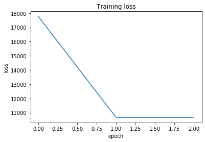

|  | user_id | avg_length_of_stay | avg_room_segment | avg_n_people |
| --- | --- | --- | --- | --- |
| 0 | 1 | 2.285714 | 2.0 | 2.214286 |
| 1 | 3 | 2.000000 | 2.0 | 2.000000 |
| 2 | 4 | 3.000000 | 2.0 | 3.000000 |
| 3 | 5 | 3.000000 | 1.0 | 2.000000 |
| 4 | 6 | 3.000000 | 3.0 | 4.000000 |
| 5 | 7 | 2.000000 | 3.0 | 4.000000 |
| 6 | 8 | 2.000000 | 2.0 | 1.000000 |
| 7 | 10 | 2.000000 | 2.0 | 3.000000 |
| 8 | 12 | 4.000000 | 2.0 | 3.000000 |
| 9 | 13 | 2.285714 | 2.0 | 1.000000 |
| 10 | 18 | 4.000000 | 2.0 | 3.000000 |
| 11 | 19 | 3.000000 | 2.0 | 3.000000 |
| 12 | 20 | 4.000000 | 3.0 | 4.000000 |
| 13 | 25 | 3.000000 | 2.0 | 3.000000 |
| 14 | 26 | 2.000000 | 3.0 | 1.000000 |

```
start negative
end negative
x.len
28166
x[0]
tensor([3., 3., 4., 0., 1., 0., 0., 0., 0., 0., 0., 0., 0., 1., 0., 1., 0., 0.,
        0., 1., 0., 0., 0., 0., 0., 1., 1., 0.], dtype=torch.float64)
ytarget.len
28166
epoch
0
y=
tensor([0.6191], grad_fn=<SigmoidBackward>)
y_target=
tensor(1)
y=
tensor([0.6140], grad_fn=<SigmoidBackward>)
y_target=
tensor(0)
loss=
tensor(8459.8096, grad_fn=<SumBackward0>)
epoch
1
y=
tensor([0.], grad_fn=<SigmoidBackward>)
y_target=
tensor(1)
y=
tensor([0.], grad_fn=<SigmoidBackward>)
y_target=
tensor(0)
loss=
tensor(10423.3320, grad_fn=<SumBackward0>)
epoch
2
y=
tensor([0.], grad_fn=<SigmoidBackward>)
y_target=
tensor(1)
y=
tensor([0.], grad_fn=<SigmoidBackward>)
y_target=
tensor(0)
loss=
tensor(10423.3223, grad_fn=<SumBackward0>)
```

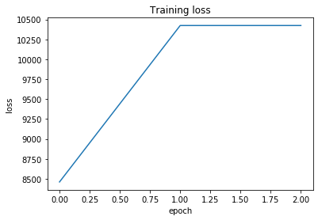

|  | user_id | avg_length_of_stay | avg_room_segment | avg_n_people |
| --- | --- | --- | --- | --- |
| 0 | 1 | 2.285714 | 2.0 | 2.214286 |
| 1 | 3 | 2.000000 | 2.0 | 2.000000 |
| 2 | 4 | 3.000000 | 2.0 | 3.000000 |
| 3 | 5 | 3.000000 | 1.0 | 2.000000 |
| 4 | 6 | 3.000000 | 3.0 | 4.000000 |
| 5 | 7 | 2.000000 | 3.0 | 4.000000 |
| 6 | 8 | 2.000000 | 2.0 | 1.000000 |
| 7 | 10 | 2.000000 | 2.0 | 3.000000 |
| 8 | 12 | 4.000000 | 2.0 | 3.000000 |
| 9 | 13 | 2.285714 | 2.0 | 1.000000 |
| 10 | 18 | 4.000000 | 2.0 | 3.000000 |
| 11 | 19 | 3.000000 | 2.0 | 3.000000 |
| 12 | 20 | 4.000000 | 3.0 | 4.000000 |
| 13 | 25 | 3.000000 | 2.0 | 3.000000 |
| 14 | 26 | 2.000000 | 3.0 | 1.000000 |

```
start negative
end negative
x.len
57654
x[0]
tensor([3., 3., 4., 0., 1., 0., 0., 0., 0., 0., 0., 0., 0., 1., 0., 1., 0., 0.,
        0., 1., 0., 0., 0., 0., 0., 1., 1., 0.], dtype=torch.float64)
ytarget.len
57654
epoch
0
y=
tensor([0.6191], grad_fn=<SigmoidBackward>)
y_target=
tensor(1)
y=
tensor([0.6140], grad_fn=<SigmoidBackward>)
y_target=
tensor(0)
loss=
tensor(20054.9395, grad_fn=<SumBackward0>)
epoch
1
y=
tensor([0.], grad_fn=<SigmoidBackward>)
y_target=
tensor(1)
y=
tensor([0.], grad_fn=<SigmoidBackward>)
y_target=
tensor(0)
loss=
tensor(10724.9014, grad_fn=<SumBackward0>)
epoch
2
y=
tensor([0.], grad_fn=<SigmoidBackward>)
y_target=
tensor(1)
y=
tensor([0.], grad_fn=<SigmoidBackward>)
y_target=
tensor(0)
loss=
tensor(10724.8936, grad_fn=<SumBackward0>)
```

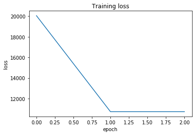

|  | user_id | avg_length_of_stay | avg_room_segment | avg_n_people |
| --- | --- | --- | --- | --- |
| 0 | 1 | 2.285714 | 2.0 | 2.214286 |
| 1 | 3 | 2.000000 | 2.0 | 2.000000 |
| 2 | 4 | 3.000000 | 2.0 | 3.000000 |
| 3 | 5 | 3.000000 | 1.0 | 2.000000 |
| 4 | 6 | 3.000000 | 3.0 | 4.000000 |
| 5 | 7 | 2.000000 | 3.0 | 4.000000 |
| 6 | 8 | 2.000000 | 2.0 | 1.000000 |
| 7 | 10 | 2.000000 | 2.0 | 3.000000 |
| 8 | 12 | 4.000000 | 2.0 | 3.000000 |
| 9 | 13 | 2.285714 | 2.0 | 1.000000 |
| 10 | 18 | 4.000000 | 2.0 | 3.000000 |
| 11 | 19 | 3.000000 | 2.0 | 3.000000 |
| 12 | 20 | 4.000000 | 3.0 | 4.000000 |
| 13 | 25 | 3.000000 | 2.0 | 3.000000 |
| 14 | 26 | 2.000000 | 3.0 | 1.000000 |

```
start negative
end negative
x.len
63539
x[0]
tensor([3., 3., 4., 0., 1., 0., 0., 0., 0., 0., 0., 0., 0., 1., 0., 1., 0., 0.,
        0., 1., 0., 0., 0., 0., 0., 1., 1., 0.], dtype=torch.float64)
ytarget.len
63539
epoch
0
y=
tensor([0.6191], grad_fn=<SigmoidBackward>)
y_target=
tensor(1)
y=
tensor([0.6140], grad_fn=<SigmoidBackward>)
y_target=
tensor(0)
loss=
tensor(22368.4941, grad_fn=<SumBackward0>)
epoch
1
y=
tensor([0.], grad_fn=<SigmoidBackward>)
y_target=
tensor(1)
y=
tensor([0.], grad_fn=<SigmoidBackward>)
y_target=
tensor(0)
loss=
tensor(10785.1338, grad_fn=<SumBackward0>)
epoch
2
y=
tensor([0.], grad_fn=<SigmoidBackward>)
y_target=
tensor(1)
y=
tensor([0.], grad_fn=<SigmoidBackward>)
y_target=
tensor(0)
loss=
tensor(10785.1250, grad_fn=<SumBackward0>)
```

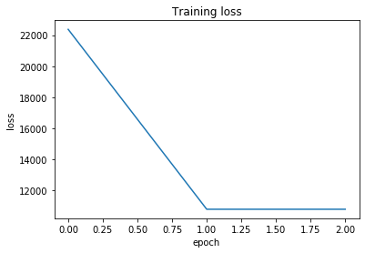

|  | user_id | avg_length_of_stay | avg_room_segment | avg_n_people |
| --- | --- | --- | --- | --- |
| 0 | 1 | 2.285714 | 2.0 | 2.214286 |
| 1 | 3 | 2.000000 | 2.0 | 2.000000 |
| 2 | 4 | 3.000000 | 2.0 | 3.000000 |
| 3 | 5 | 3.000000 | 1.0 | 2.000000 |
| 4 | 6 | 3.000000 | 3.0 | 4.000000 |
| 5 | 7 | 2.000000 | 3.0 | 4.000000 |
| 6 | 8 | 2.000000 | 2.0 | 1.000000 |
| 7 | 10 | 2.000000 | 2.0 | 3.000000 |
| 8 | 12 | 4.000000 | 2.0 | 3.000000 |
| 9 | 13 | 2.285714 | 2.0 | 1.000000 |
| 10 | 18 | 4.000000 | 2.0 | 3.000000 |
| 11 | 19 | 3.000000 | 2.0 | 3.000000 |
| 12 | 20 | 4.000000 | 3.0 | 4.000000 |
| 13 | 25 | 3.000000 | 2.0 | 3.000000 |
| 14 | 26 | 2.000000 | 3.0 | 1.000000 |

```
start negative
end negative
x.len
51835
x[0]
tensor([3., 3., 4., 0., 1., 0., 0., 0., 0., 0., 0., 0., 0., 1., 0., 1., 0., 0.,
        0., 1., 0., 0., 0., 0., 0., 1., 1., 0.], dtype=torch.float64)
ytarget.len
51835
epoch
0
y=
tensor([0.6191], grad_fn=<SigmoidBackward>)
y_target=
tensor(1)
y=
tensor([0.6140], grad_fn=<SigmoidBackward>)
y_target=
tensor(0)
loss=
tensor(17767.0996, grad_fn=<SumBackward0>)
epoch
1
y=
tensor([0.], grad_fn=<SigmoidBackward>)
y_target=
tensor(1)
y=
tensor([0.], grad_fn=<SigmoidBackward>)
y_target=
tensor(0)
loss=
tensor(10665.3418, grad_fn=<SumBackward0>)
epoch
2
y=
tensor([0.], grad_fn=<SigmoidBackward>)
y_target=
tensor(1)
y=
tensor([0.], grad_fn=<SigmoidBackward>)
y_target=
tensor(0)
loss=
tensor(10665.3330, grad_fn=<SumBackward0>)
```

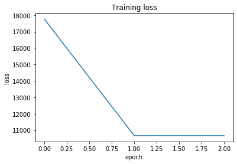

|  | user_id | avg_length_of_stay | avg_room_segment | avg_n_people |
| --- | --- | --- | --- | --- |
| 0 | 1 | 2.285714 | 2.0 | 2.214286 |
| 1 | 3 | 2.000000 | 2.0 | 2.000000 |
| 2 | 4 | 3.000000 | 2.0 | 3.000000 |
| 3 | 5 | 3.000000 | 1.0 | 2.000000 |
| 4 | 6 | 3.000000 | 3.0 | 4.000000 |
| 5 | 7 | 2.000000 | 3.0 | 4.000000 |
| 6 | 8 | 2.000000 | 2.0 | 1.000000 |
| 7 | 10 | 2.000000 | 2.0 | 3.000000 |
| 8 | 12 | 4.000000 | 2.0 | 3.000000 |
| 9 | 13 | 2.285714 | 2.0 | 1.000000 |
| 10 | 18 | 4.000000 | 2.0 | 3.000000 |
| 11 | 19 | 3.000000 | 2.0 | 3.000000 |
| 12 | 20 | 4.000000 | 3.0 | 4.000000 |
| 13 | 25 | 3.000000 | 2.0 | 3.000000 |
| 14 | 26 | 2.000000 | 3.0 | 1.000000 |

```
start negative
end negative
x.len
69475
x[0]
tensor([3., 3., 4., 0., 1., 0., 0., 0., 0., 0., 0., 0., 0., 1., 0., 1., 0., 0.,
        0., 1., 0., 0., 0., 0., 0., 1., 1., 0.], dtype=torch.float64)
ytarget.len
69475
epoch
0
y=
tensor([0.6191], grad_fn=<SigmoidBackward>)
y_target=
tensor(1)
y=
tensor([0.6140], grad_fn=<SigmoidBackward>)
y_target=
tensor(0)
loss=
tensor(24703.9980, grad_fn=<SumBackward0>)
epoch
1
y=
tensor([0.], grad_fn=<SigmoidBackward>)
y_target=
tensor(1)
y=
tensor([0.], grad_fn=<SigmoidBackward>)
y_target=
tensor(0)
loss=
tensor(10845.8389, grad_fn=<SumBackward0>)
epoch
2
y=
tensor([0.], grad_fn=<SigmoidBackward>)
y_target=
tensor(1)
y=
tensor([0.], grad_fn=<SigmoidBackward>)
y_target=
tensor(0)
loss=
tensor(10845.8311, grad_fn=<SumBackward0>)
```

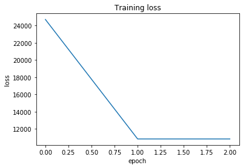

|  | user_id | avg_length_of_stay | avg_room_segment | avg_n_people |
| --- | --- | --- | --- | --- |
| 0 | 1 | 2.285714 | 2.0 | 2.214286 |
| 1 | 3 | 2.000000 | 2.0 | 2.000000 |
| 2 | 4 | 3.000000 | 2.0 | 3.000000 |
| 3 | 5 | 3.000000 | 1.0 | 2.000000 |
| 4 | 6 | 3.000000 | 3.0 | 4.000000 |
| 5 | 7 | 2.000000 | 3.0 | 4.000000 |
| 6 | 8 | 2.000000 | 2.0 | 1.000000 |
| 7 | 10 | 2.000000 | 2.0 | 3.000000 |
| 8 | 12 | 4.000000 | 2.0 | 3.000000 |
| 9 | 13 | 2.285714 | 2.0 | 1.000000 |
| 10 | 18 | 4.000000 | 2.0 | 3.000000 |
| 11 | 19 | 3.000000 | 2.0 | 3.000000 |
| 12 | 20 | 4.000000 | 3.0 | 4.000000 |
| 13 | 25 | 3.000000 | 2.0 | 3.000000 |
| 14 | 26 | 2.000000 | 3.0 | 1.000000 |

```
start negative
end negative
x.len
63539
x[0]
tensor([3., 3., 4., 0., 1., 0., 0., 0., 0., 0., 0., 0., 0., 1., 0., 1., 0., 0.,
        0., 1., 0., 0., 0., 0., 0., 1., 1., 0.], dtype=torch.float64)
ytarget.len
63539
epoch
0
y=
tensor([0.6191], grad_fn=<SigmoidBackward>)
y_target=
tensor(1)
y=
tensor([0.6140], grad_fn=<SigmoidBackward>)
y_target=
tensor(0)
loss=
tensor(22368.4941, grad_fn=<SumBackward0>)
epoch
1
y=
tensor([0.], grad_fn=<SigmoidBackward>)
y_target=
tensor(1)
y=
tensor([0.], grad_fn=<SigmoidBackward>)
y_target=
tensor(0)
loss=
tensor(10785.1338, grad_fn=<SumBackward0>)
epoch
2
y=
tensor([0.], grad_fn=<SigmoidBackward>)
y_target=
tensor(1)
y=
tensor([0.], grad_fn=<SigmoidBackward>)
y_target=
tensor(0)
loss=
tensor(10785.1250, grad_fn=<SumBackward0>)
```

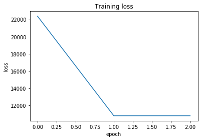

|  | user_id | avg_length_of_stay | avg_room_segment | avg_n_people |
| --- | --- | --- | --- | --- |
| 0 | 1 | 2.277778 | 2.055556 | 2.277778 |
| 1 | 2 | 2.000000 | 2.000000 | 3.000000 |
| 2 | 3 | 2.000000 | 2.000000 | 2.000000 |
| 3 | 4 | 3.000000 | 2.000000 | 3.000000 |
| 4 | 5 | 3.000000 | 1.000000 | 2.000000 |
| 5 | 6 | 3.000000 | 3.000000 | 4.000000 |
| 6 | 7 | 2.000000 | 3.000000 | 4.000000 |
| 7 | 8 | 2.000000 | 2.000000 | 1.000000 |
| 8 | 10 | 2.000000 | 2.000000 | 3.000000 |
| 9 | 11 | 2.000000 | 2.000000 | 3.000000 |
| 10 | 12 | 4.000000 | 2.000000 | 3.000000 |
| 11 | 13 | 2.500000 | 2.125000 | 1.000000 |
| 12 | 16 | 3.000000 | 2.000000 | 3.000000 |
| 13 | 17 | 3.000000 | 1.000000 | 3.000000 |
| 14 | 18 | 4.000000 | 2.000000 | 3.000000 |

```
start negative
end negative
x.len 110097
x[0] tensor([3., 2., 3., 0., 0., 1., 0., 0., 0., 0., 0., 0., 0., 1., 0., 0., 1., 0.,
        1., 0., 0., 0., 0., 0., 1., 0., 1., 0.], dtype=torch.float64)
ytarget.len 110097
epoch 0
y= tensor([0.6263], grad_fn=<SigmoidBackward>)
y_target= tensor(1)
y= tensor([0.6263], grad_fn=<SigmoidBackward>)
y_target= tensor(1)
loss= tensor(40017.7617, grad_fn=<SumBackward0>)
epoch 1
y= tensor([0.], grad_fn=<SigmoidBackward>)
y_target= tensor(1)
y= tensor([0.], grad_fn=<SigmoidBackward>)
y_target= tensor(1)
loss= tensor(13795.7559, grad_fn=<SumBackward0>)
epoch 2
y= tensor([0.], grad_fn=<SigmoidBackward>)
y_target= tensor(1)
y= tensor([0.], grad_fn=<SigmoidBackward>)
y_target= tensor(1)
loss= tensor(13795.7480, grad_fn=<SumBackward0>)
```

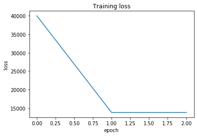

|  | Recommender | HR@1 | HR@3 | HR@5 | HR@10 | NDCG@1 | NDCG@3 | NDCG@5 | NDCG@10 |
| --- | --- | --- | --- | --- | --- | --- | --- | --- | --- |
| 0 | NNRecommender | 0.003949 | 0.011846 | 0.019743 | 0.039487 | 0.003949 | 0.008414 | 0.011642 | 0.017941 |

```
Best parameters:
{'n_neg_per_pos': 10.0}
```

```python
param_space = {
    'n_neg_per_pos': hp.quniform('n_neg_per_pos', 1, 10, 1)
}

best_param_set = tune_recommender(NNRecommender, interactions_df, items_df,
                                  param_space, max_evals=10, show_progressbar=True, seed=seed)

print("Best parameters:")
print(best_param_set)
```

# Final evaluation

**Task:**  
Run the final evaluation of your recommender and present its results against the Amazon and Netflix recommenders' results. You just need to give the class name of your recommender and its tuned parameters below.

|  | user_id | avg_length_of_stay | avg_room_segment | avg_n_people |
| --- | --- | --- | --- | --- |
| 0 | 1 | 2.277778 | 2.055556 | 2.277778 |
| 1 | 2 | 2.000000 | 2.000000 | 3.000000 |
| 2 | 3 | 2.000000 | 2.000000 | 2.000000 |
| 3 | 4 | 3.000000 | 2.000000 | 3.000000 |
| 4 | 5 | 3.000000 | 1.000000 | 2.000000 |
| 5 | 6 | 3.000000 | 3.000000 | 4.000000 |
| 6 | 7 | 2.000000 | 3.000000 | 4.000000 |
| 7 | 8 | 2.000000 | 2.000000 | 1.000000 |
| 8 | 10 | 2.000000 | 2.000000 | 3.000000 |
| 9 | 11 | 2.000000 | 2.000000 | 3.000000 |
| 10 | 12 | 4.000000 | 2.000000 | 3.000000 |
| 11 | 13 | 2.500000 | 2.125000 | 1.000000 |
| 12 | 16 | 3.000000 | 2.000000 | 3.000000 |
| 13 | 17 | 3.000000 | 1.000000 | 3.000000 |
| 14 | 18 | 4.000000 | 2.000000 | 3.000000 |

```
start negative
end negative
x.len 22604
x[0] tensor([3., 2., 3., 0., 0., 1., 0., 0., 0., 0., 0., 0., 0., 1., 0., 0., 1., 0.,
        1., 0., 0., 0., 0., 0., 1., 0., 1., 0.], dtype=torch.float64)
ytarget.len 22604
epoch 0
y= tensor([0.6263], grad_fn=<SigmoidBackward>)
y_target= tensor(1)
y= tensor([0.6263], grad_fn=<SigmoidBackward>)
y_target= tensor(1)
loss= tensor(5616.4180, grad_fn=<SumBackward0>)
epoch 1
y= tensor([7.6745e-11], grad_fn=<SigmoidBackward>)
y_target= tensor(1)
y= tensor([7.6745e-11], grad_fn=<SigmoidBackward>)
y_target= tensor(1)
loss= tensor(12902.2295, grad_fn=<SumBackward0>)
epoch 2
y= tensor([7.7282e-11], grad_fn=<SigmoidBackward>)
y_target= tensor(1)
y= tensor([7.7282e-11], grad_fn=<SigmoidBackward>)
y_target= tensor(1)
loss= tensor(12902.2217, grad_fn=<SumBackward0>)
```

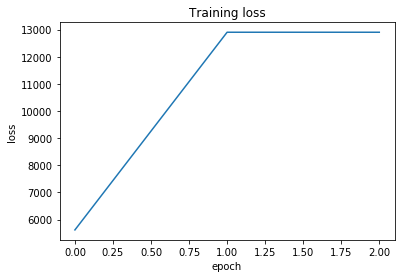

|  | Recommender | HR@1 | HR@3 | HR@5 | HR@10 | NDCG@1 | NDCG@3 | NDCG@5 | NDCG@10 |
| --- | --- | --- | --- | --- | --- | --- | --- | --- | --- |
| 0 | NNRecommender | 0.003949 | 0.011846 | 0.019743 | 0.039487 | 0.003949 | 0.008414 | 0.011642 | 0.017941 |

```python
nn_recommender = NNRecommender(n_neg_per_pos=1)  # Initialize your recommender here

# Give the name of your recommender in the line below
nn_tts_results = [['NNRecommender'] + list(evaluate_train_test_split_implicit(
    nn_recommender, interactions_df, items_df))]

nn_tts_results = pd.DataFrame(
    nn_tts_results, columns=['Recommender', 'HR@1', 'HR@3', 'HR@5', 'HR@10', 'NDCG@1', 'NDCG@3', 'NDCG@5', 'NDCG@10'])

display(HTML(nn_tts_results.to_html()))
```

```python
from recommenders.amazon_recommender import AmazonRecommender

amazon_recommender = AmazonRecommender()

amazon_tts_results = [['AmazonRecommender'] + list(evaluate_train_test_split_implicit(
    amazon_recommender, interactions_df, items_df))]

amazon_tts_results = pd.DataFrame(
    amazon_tts_results, columns=['Recommender', 'HR@1', 'HR@3', 'HR@5', 'HR@10', 'NDCG@1', 'NDCG@3', 'NDCG@5', 'NDCG@10'])

display(HTML(amazon_tts_results.to_html()))
```

|  | Recommender | HR@1 | HR@3 | HR@5 | HR@10 | NDCG@1 | NDCG@3 | NDCG@5 | NDCG@10 |
| --- | --- | --- | --- | --- | --- | --- | --- | --- | --- |
| 0 | AmazonRecommender | 0.042119 | 0.10464 | 0.140507 | 0.199408 | 0.042119 | 0.076826 | 0.091797 | 0.110705 |

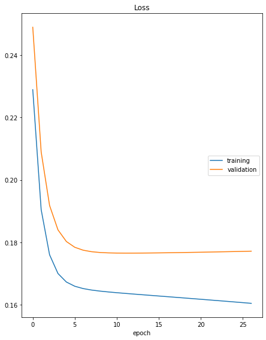

```
Loss
	training         	 (min:    0.160, max:    0.229, cur:    0.160)
	validation       	 (min:    0.177, max:    0.249, cur:    0.177)
```

|  | Recommender | HR@1 | HR@3 | HR@5 | HR@10 | NDCG@1 | NDCG@3 | NDCG@5 | NDCG@10 |
| --- | --- | --- | --- | --- | --- | --- | --- | --- | --- |
| 0 | NetflixRecommender | 0.042777 | 0.107272 | 0.144784 | 0.201711 | 0.042777 | 0.078557 | 0.094208 | 0.112401 |

```python
from recommenders.netflix_recommender import NetflixRecommender

netflix_recommender = NetflixRecommender(n_epochs=30, print_type='live')

netflix_tts_results = [['NetflixRecommender'] + list(evaluate_train_test_split_implicit(
    netflix_recommender, interactions_df, items_df))]

netflix_tts_results = pd.DataFrame(
    netflix_tts_results, columns=['Recommender', 'HR@1', 'HR@3', 'HR@5', 'HR@10', 'NDCG@1', 'NDCG@3', 'NDCG@5', 'NDCG@10'])

display(HTML(netflix_tts_results.to_html()))
```

```python
tts_results = pd.concat([nn_tts_results, amazon_tts_results, netflix_tts_results]).reset_index(drop=True)
display(HTML(tts_results.to_html()))
```

|  | Recommender | HR@1 | HR@3 | HR@5 | HR@10 | NDCG@1 | NDCG@3 | NDCG@5 | NDCG@10 |
| --- | --- | --- | --- | --- | --- | --- | --- | --- | --- |
| 0 | NNRecommender | 0.003949 | 0.011846 | 0.019743 | 0.039487 | 0.003949 | 0.008414 | 0.011642 | 0.017941 |
| 1 | AmazonRecommender | 0.042119 | 0.104640 | 0.140507 | 0.199408 | 0.042119 | 0.076826 | 0.091797 | 0.110705 |
| 2 | NetflixRecommender | 0.042777 | 0.107272 | 0.144784 | 0.201711 | 0.042777 | 0.078557 | 0.094208 | 0.112401 |

# Summary

**Task:**  
Write a summary of your experiments. What worked well and what did not? What are your thoughts how could you possibly further improve the model?

```python
# Unfortunately, I don't know why my recommender always return item: 0. I haven't got gpu so fitting, testing and
# others was hassle to me. So then I gave up.
# I think I could get better results if I had gpu. With more epochs
# or more n_neg_per_pos my recommender could be better but my computer was crashing.
# And because of lack of time (due to private stuff) I couldn't achieve too much.
# I didn't test various network architectures too.
# Interesting is fact that I achieve even better hr10 score like in first project.
```